# Transforming Health and Social Care Publications in Scotland

March 13, 2019  
Slides: https://github.com/NHS-NSS-transforming-publications/NTTS2019

## Background

- The Information Services Division (ISD) of the National Health Service (NHS) Scotland produces around 200 official and national statistics publications each year.
- Traditional publication format is a **static pdf document** with accompanying **excel tables**.
- Production uses **proprietary software** and is **time-consuming**, involving extensive manual formatting and checking.

[figure not shown]

## Transforming Publishing Vision

[figure not shown]

## Initial User Engagement

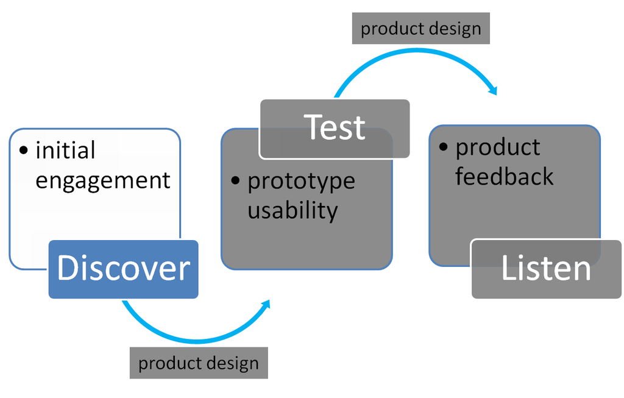

## Initial User Engagement

- Focus groups and interviews with over 10 different user groups.
- Determined user experiences of existing product and how the new product design could meet their needs.
- Created user stories which influenced the features of the minimum viable product.

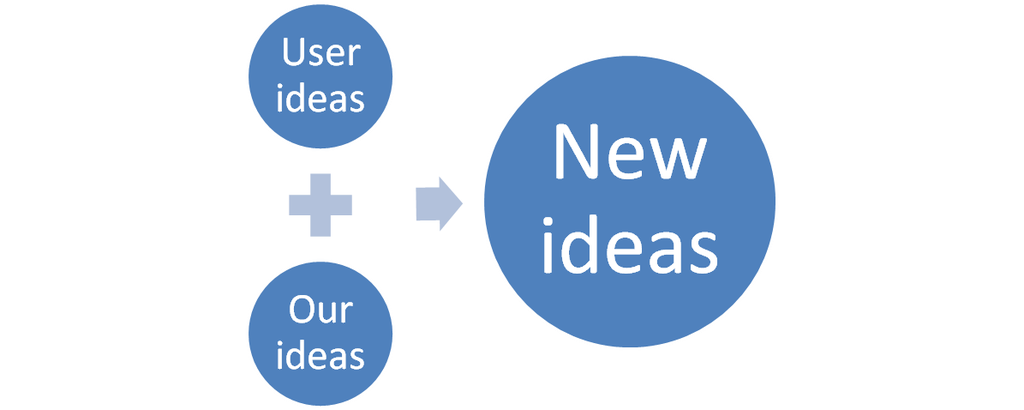

## Minimum Viable Product (MVP)

[figure not shown]

## MVP: Data Explorer

[figure not shown]

[Acute Activity data explorer](https://www.isdscotland.org/Health-Topics/Hospital-Care/Publications/2018-06-26/Acute-Hospital-Publication/data-explorer/)  
[R Shiny code](https://github.com/Health-SocialCare-Scotland/Hospital-Acute-Activity/tree/master/Data-Explorer)

## User Testing the Data Explorer

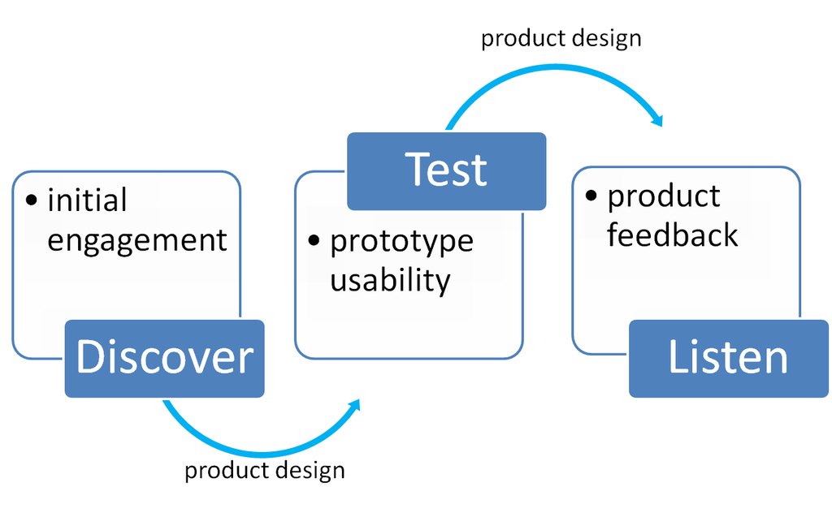

- To determine how the explorer **works in practice**, and identify potential **faults or usability issues**.
- In general, feedback indicates that the core  
  functionality of the explorer is **highly usable**.

## User Feedback

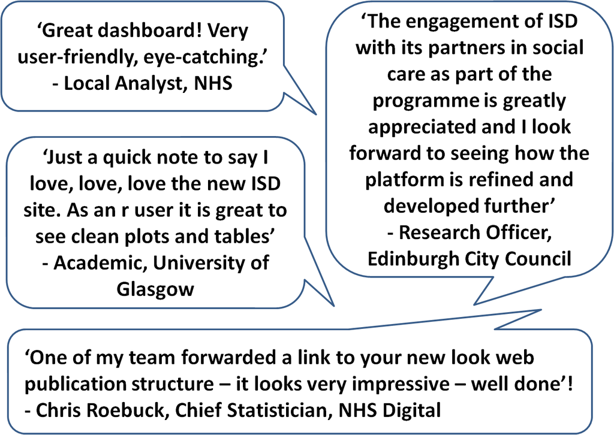

## The Challenge of Scaling

- ISD website
- R knowledge within ISD:
  - R training at an organisation level
  - [R Style Guide](https://github.com/Health-SocialCare-Scotland/R-Resources/blob/master/PHI%20R%20style%20guide.md)
  - Blank [R Project](https://github.com/Health-SocialCare-Scotland/r-project-structure) and [R Shiny](https://github.com/Health-SocialCare-Scotland/rshiny-project-structure) templates
  - [Resources](https://github.com/NHS-NSS-transforming-publications/resources)
- Consistency of Shiny dashboards:
  - Share [R Shiny code](https://github.com/Health-SocialCare-Scotland/Hospital-Acute-Activity/tree/master/Data-Explorer) for the original data explorer
  - Current development: design guidance
- IT infrastructure

## Next Steps

- [Psychiatric Inpatient Activity publication](https://www.isdscotland.org/Health-Topics/Mental-Health/Publications/2018-09-25/psychiatric-inpatient-activity/) was released on the new platform in September 2018.
- Focus this year is on user research and automating the production process using [Reproducible Analytical Pipelines](https://ukgovdatascience.github.io/rap_companion/).
- Toolkit and buddy system to enable this.

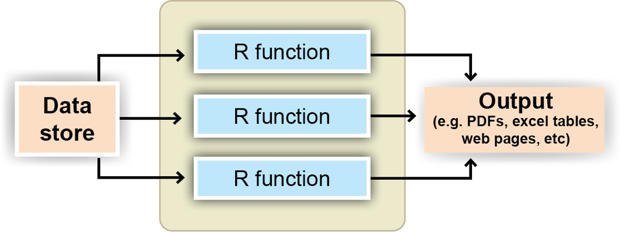

## Thank You

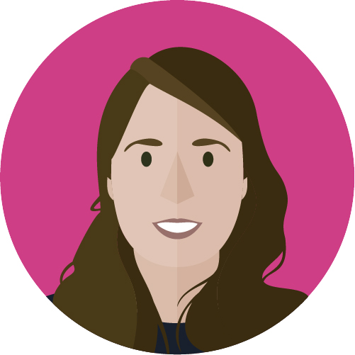

[figure not shown]

@price_AH

[figure not shown]

annahprice  
anna.price5@nhs.net

**Want to keep up to date with our latest developments?** Email us to be added to our quarterly newsletter: nss.isdtransformingpublishing@nhs.net

Transforming Publishing on GitHub:  
https://github.com/NHS-NSS-transforming-publications

ISD on GitHub: https://github.com/Health-SocialCare-Scotland